# Project Code

SLB

Author

Fauzan Aryaputra, Ethan Sterling, Daniel Leshem, Joel Kim

Published

December 4, 2023

Abstract

*This file contains the code for the project on Heart Attack Indicators, as part of the STAT303-1 course in Fall 2023*.

## 1 Data quality check / cleaning / preparation

```python
import pandas as pd
import numpy as np
import seaborn as sns
import matplotlib.pyplot as plt
import scipy
from scipy.stats import ttest_ind, chi2_contingency
import plotly.graph_objects as go

#data import
heart_data = pd.read_csv('heart_2022_with_nans.csv')
heart_data.head()
```

|  | State | Sex | GeneralHealth | PhysicalHealthDays | MentalHealthDays | LastCheckupTime | PhysicalActivities | SleepHours | RemovedTeeth | HadHeartAttack | ... | HeightInMeters | WeightInKilograms | BMI | AlcoholDrinkers | HIVTesting | FluVaxLast12 | PneumoVaxEver | TetanusLast10Tdap | HighRiskLastYear | CovidPos |
| --- | --- | --- | --- | --- | --- | --- | --- | --- | --- | --- | --- | --- | --- | --- | --- | --- | --- | --- | --- | --- | --- |
| 0 | Alabama | Female | Very good | 0.0 | 0.0 | Within past year (anytime less than 12 months ... | No | 8.0 | NaN | No | ... | NaN | NaN | NaN | No | No | Yes | No | Yes, received tetanus shot but not sure what type | No | No |
| 1 | Alabama | Female | Excellent | 0.0 | 0.0 | NaN | No | 6.0 | NaN | No | ... | 1.60 | 68.04 | 26.57 | No | No | No | No | No, did not receive any tetanus shot in the pa... | No | No |
| 2 | Alabama | Female | Very good | 2.0 | 3.0 | Within past year (anytime less than 12 months ... | Yes | 5.0 | NaN | No | ... | 1.57 | 63.50 | 25.61 | No | No | No | No | NaN | No | Yes |
| 3 | Alabama | Female | Excellent | 0.0 | 0.0 | Within past year (anytime less than 12 months ... | Yes | 7.0 | NaN | No | ... | 1.65 | 63.50 | 23.30 | No | No | Yes | Yes | No, did not receive any tetanus shot in the pa... | No | No |
| 4 | Alabama | Female | Fair | 2.0 | 0.0 | Within past year (anytime less than 12 months ... | Yes | 9.0 | NaN | No | ... | 1.57 | 53.98 | 21.77 | Yes | No | No | Yes | No, did not receive any tetanus shot in the pa... | No | No |

5 rows × 40 columns

```python
heart_data.shape
```

```
(445132, 40)
```

**2022 annual CDC survey data of 400k+ adults related to their health status What subject does the dataset cover?** According to the CDC, heart disease is a leading cause of death for people of most races in the U.S. (African Americans, American Indians and Alaska Natives, and whites). About half of all Americans (47%) have at least 1 of 3 major risk factors for heart disease: high blood pressure, high cholesterol, and smoking. Other key indicators include diabetes status, obesity (high BMI), not getting enough physical activity, or drinking too much alcohol. Identifying and preventing the factors that have the greatest impact on heart disease is very important in healthcare.

### 1.1 Distribution of response

*By Daniel Leshem*

```python
# Daniel Leshem did this for the presentation
```

### 1.2 Data cleaning

*By SLB*

```python
print(f'Missing values: {heart_data.isnull().sum().sum()}')
```

```
Missing values: 902665
```

Hypothetically, further cleaning can be done but we decided as a group to clean all of our data separately as the variety in missing values and difference in EDA questions means that we do not want to eliminate values that may not apply to one person’s question but does apply to anothers.

### 1.3 Data preparation

*By SLB*

The following data preparation steps helped us to prepare our data for implementing various modeling / validation techniques:

1. New variables
2. New data frames

We all did our own data preparation that suited our needs, as will be seen in our own EDA sections below.

## 2 Exploratory data analysis

### 2.1 Demographic Analysis

*By Daniel Leshem*

Which demographic groups are most susceptible to heart attacks?

```python
heart_data.columns
#relevant ones 'RaceEthnicityCategory' 'Sex' 'HadHeartAttack'
```

```
Index(['State', 'Sex', 'GeneralHealth', 'PhysicalHealthDays',
       'MentalHealthDays', 'LastCheckupTime', 'PhysicalActivities',
       'SleepHours', 'RemovedTeeth', 'HadHeartAttack', 'HadAngina',
       'HadStroke', 'HadAsthma', 'HadSkinCancer', 'HadCOPD',
       'HadDepressiveDisorder', 'HadKidneyDisease', 'HadArthritis',
       'HadDiabetes', 'DeafOrHardOfHearing', 'BlindOrVisionDifficulty',
       'DifficultyConcentrating', 'DifficultyWalking',
       'DifficultyDressingBathing', 'DifficultyErrands', 'SmokerStatus',
       'ECigaretteUsage', 'ChestScan', 'RaceEthnicityCategory', 'AgeCategory',
       'HeightInMeters', 'WeightInKilograms', 'BMI', 'AlcoholDrinkers',
       'HIVTesting', 'FluVaxLast12', 'PneumoVaxEver', 'TetanusLast10Tdap',
       'HighRiskLastYear', 'CovidPos'],
      dtype='object')
```

```python
# hypothesis test: we'll compare them all to white only, non-hispanic
selected_cols = ['HadHeartAttack','RaceEthnicityCategory']
daniel_data = heart_data[selected_cols]
daniel_data = pd.get_dummies(daniel_data,drop_first=True)
daniel_data.columns
```

```
Index(['HadHeartAttack_Yes', 'RaceEthnicityCategory_Hispanic',
       'RaceEthnicityCategory_Multiracial, Non-Hispanic',
       'RaceEthnicityCategory_Other race only, Non-Hispanic',
       'RaceEthnicityCategory_White only, Non-Hispanic'],
      dtype='object')
```

```python
heart_data
dummies = pd.get_dummies(heart_data['HadHeartAttack'], prefix='HadHeartAttack')
heart_data_dummies = heart_data


heart_data_dummies['dummy'] = dummies['HadHeartAttack_Yes']
```

```python
mean_heart_attack_by_race = heart_data_dummies.groupby('RaceEthnicityCategory')['dummy'].mean()
mean_heart_attack_by_race.sort_values(ascending=False)
```

```
RaceEthnicityCategory
Multiracial, Non-Hispanic        0.061495
White only, Non-Hispanic         0.060299
Black only, Non-Hispanic         0.047340
Other race only, Non-Hispanic    0.045348
Hispanic                         0.037864
Name: dummy, dtype: float64
```

[output not shown]

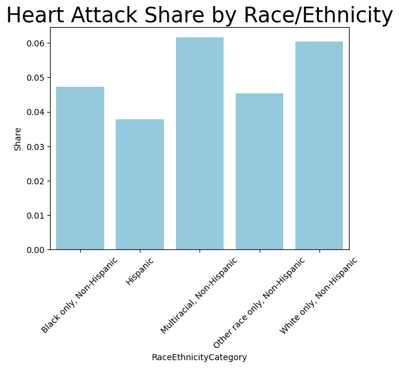

```python
sns.barplot(x=mean_heart_attack_by_race.index, y=mean_heart_attack_by_race.values,color='skyblue')
plt.title('Heart Attack Share by Race/Ethnicity',size=25)
plt.ylabel('Share')
plt.xticks(rotation=45)
```

```python
# Create a new dataframe with only 'White' and 'Nonwhite' columns
new_df = daniel_data

# Summing up all non-white columns to create 'Nonwhite' column
new_df['Nonwhite'] = new_df[['RaceEthnicityCategory_Hispanic',
       'RaceEthnicityCategory_Multiracial, Non-Hispanic',
       'RaceEthnicityCategory_Other race only, Non-Hispanic',
       'RaceEthnicityCategory_White only, Non-Hispanic']].sum(axis=1)

# Drop unnecessary columns

# Display the new dataframe

columns = ['Nonwhite','RaceEthnicityCategory_White only, Non-Hispanic','HadHeartAttack_Yes']
new_df = new_df[columns]
```

```python
from scipy.stats import chi2_contingency




# Create a contingency table
contingency_table = pd.crosstab(new_df['HadHeartAttack_Yes'], [new_df['RaceEthnicityCategory_White only, Non-Hispanic'], new_df['Nonwhite']])

# Perform the chi-squared test
chi2, p, _, expected = chi2_contingency(contingency_table)

# Output the results
print(f"Chi-squared value: {chi2}")
print(f"P-value: {p}")

# Check significance level (e.g., alpha = 0.05)
alpha = 0.05
if p < alpha:
    print("The association between race and the likelihood of having a heart attack is statistically significant.")
else:
    print("There is no significant association between race and the likelihood of having a heart attack.")
```

```
Chi-squared value: 363.72463082932825
P-value: 1.042797423023592e-79
The association between race and the likelihood of having a heart attack is statistically significant.
```

```python
new_df['sex'] = heart_data['Sex']

new_df
```

|  | Nonwhite | RaceEthnicityCategory_White only, Non-Hispanic | HadHeartAttack_Yes | sex |
| --- | --- | --- | --- | --- |
| 0 | 1 | True | False | Female |
| 1 | 1 | True | False | Female |
| 2 | 1 | True | False | Female |
| 3 | 1 | True | False | Female |
| 4 | 1 | True | False | Female |
| ... | ... | ... | ... | ... |
| 445127 | 0 | False | False | Female |
| 445128 | 0 | False | False | Female |
| 445129 | 0 | False | False | Female |
| 445130 | 0 | False | True | Male |
| 445131 | 0 | False | False | Male |

445132 rows × 4 columns

```python
# Create a contingency table
contingency_table = pd.crosstab(new_df['HadHeartAttack_Yes'], new_df['sex'])

# Perform the chi-squared test
chi2, p, _, expected = chi2_contingency(contingency_table)

# Output the results
print(f"Chi-squared value: {chi2}")
print(f"P-value: {p}")

# Check significance level (e.g., alpha = 0.05)
alpha = 0.05
if p < alpha:
    print("The association between sex and the likelihood of having a heart attack is statistically significant.")
else:
    print("There is no significant association between sex and the likelihood of having a heart attack.")
```

```
Chi-squared value: 2213.357338056751
P-value: 0.0
The association between sex and the likelihood of having a heart attack is statistically significant.
```

```
(array([0, 1]), [Text(0, 0, 'Female'), Text(1, 0, 'Male')])
```

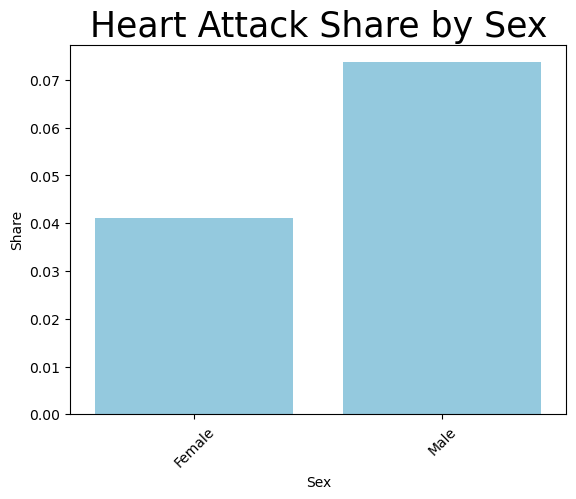

```python
heart_data
dummies = pd.get_dummies(heart_data['HadHeartAttack'], prefix='HadHeartAttack')
heart_data_dummies = heart_data


heart_data_dummies['dummy'] = dummies['HadHeartAttack_Yes']
heart_data_dummies['male']=heart_data_dummies['Sex'].apply(lambda x: 1 if x == 'Male' else 0)
heart_data_dummies

mean_heart_attack_by_race = heart_data_dummies.groupby('Sex')['dummy'].mean()



sns.barplot(x=mean_heart_attack_by_race.index, y=mean_heart_attack_by_race.values,color='skyblue')
plt.title('Heart Attack Share by Sex',size=25)
plt.ylabel('Share')

plt.xticks(rotation=45)
```

```python
heart_data['RaceEthnicityCategory'].value_counts()
```

```
RaceEthnicityCategory
White only, Non-Hispanic         320421
Hispanic                          42917
Black only, Non-Hispanic          35446
Other race only, Non-Hispanic     22713
Multiracial, Non-Hispanic          9578
Name: count, dtype: int64
```

```
(array([0, 1]), [Text(0, 0, 'Female'), Text(1, 0, 'Male')])
```

[figure not shown]

```python
heart_data_white = heart_data.loc[heart_data['RaceEthnicityCategory']=='White only, Non-Hispanic']
dummies = pd.get_dummies(heart_data['HadHeartAttack'], prefix='HadHeartAttack')
heart_data_dummies = heart_data


heart_data_dummies['dummy'] = dummies['HadHeartAttack_Yes']
heart_data_dummies['male']=heart_data_dummies['Sex'].apply(lambda x: 1 if x == 'Male' else 0)
heart_data_dummies

mean_heart_attack_by_race = heart_data_dummies.groupby('Sex')['dummy'].mean()



sns.barplot(x=mean_heart_attack_by_race.index, y=mean_heart_attack_by_race.values,color='skyblue')
plt.title('Heart Attack Share by Sex For White Individuals',size=25)
plt.ylabel('Share')

plt.xticks(rotation=45)
```

```python
mean_heart_attack_by_race.values
```

```
array([0.04108219, 0.07368129])
```

```
(array([0, 1]), [Text(0, 0, 'Female'), Text(1, 0, 'Male')])
```

[figure not shown]

```python
heart_data_white = heart_data.loc[heart_data['RaceEthnicityCategory']!='White only, Non-Hispanic']
dummies = pd.get_dummies(heart_data['HadHeartAttack'], prefix='HadHeartAttack')
heart_data_dummies = heart_data


heart_data_dummies['dummy'] = dummies['HadHeartAttack_Yes']
heart_data_dummies['male']=heart_data_dummies['Sex'].apply(lambda x: 1 if x == 'Male' else 0)
heart_data_dummies

mean_heart_attack_by_race = heart_data_dummies.groupby('Sex')['dummy'].mean()



sns.barplot(x=mean_heart_attack_by_race.index, y=mean_heart_attack_by_race.values,color='skyblue')
plt.title('Heart Attack Share by Sex For Racial and Ethnic Minorities',size=25)
plt.ylabel('Share')

plt.xticks(rotation=45)
```

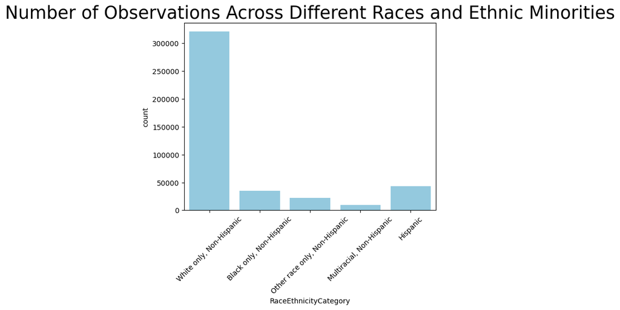

```python
sns.countplot(data=heart_data,x = heart_data['RaceEthnicityCategory'],color='skyblue')
plt.xticks(rotation=45)
plt.title('Number of Observations Across Different Races and Ethnic Minorities',size=25)
```

```python
heart_data['RaceEthnicityCategory'].value_counts()
```

```
RaceEthnicityCategory
White only, Non-Hispanic         320421
Hispanic                          42917
Black only, Non-Hispanic          35446
Other race only, Non-Hispanic     22713
Multiracial, Non-Hispanic          9578
Name: count, dtype: int64
```

```python
320421/len(heart_data)
```

```
0.7198336673166611
```

```python
heart_data['Sex'].value_counts()
```

```
Sex
Female    235893
Male      209239
Name: count, dtype: int64
```

```python
235893/(235893+209239)
```

```
0.5299394336960722
```

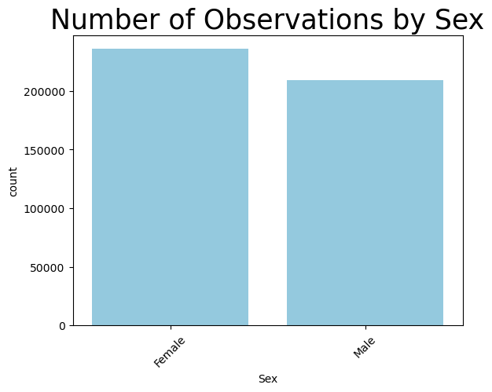

```python
sns.countplot(data=heart_data,x = heart_data['Sex'],color='skyblue')
plt.xticks(rotation=45)
plt.title('Number of Observations by Sex',size=25)
```

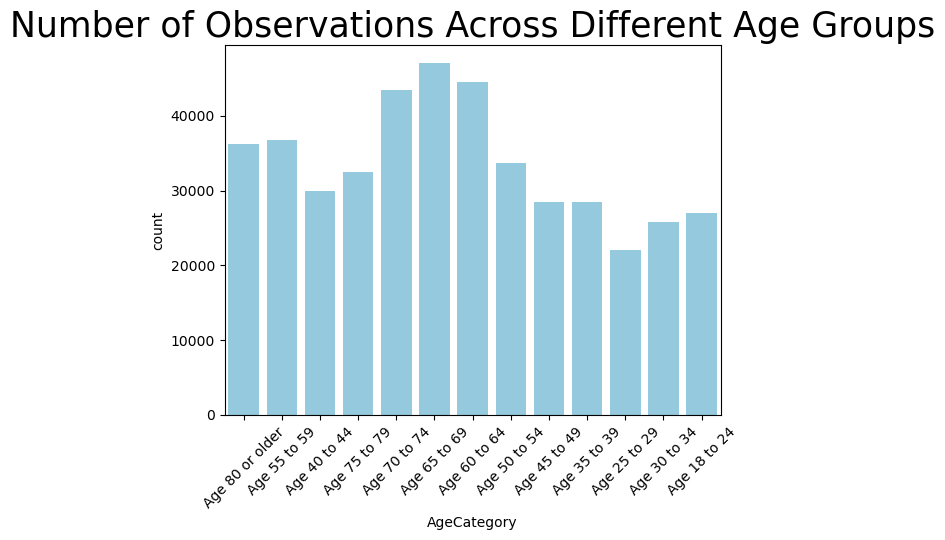

```python
sns.countplot(data=heart_data,x = heart_data['AgeCategory'],color='skyblue')
plt.xticks(rotation=45)
plt.title('Number of Observations Across Different Age Groups',size=25)
```

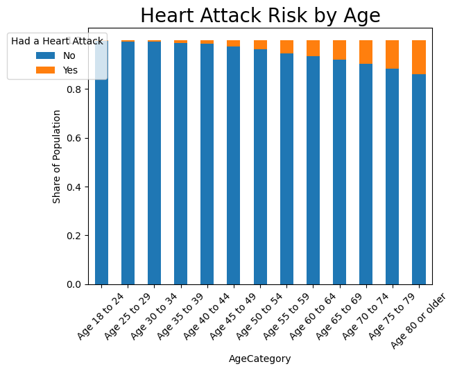

```python
age_prop = pd.crosstab(index=heart_data['AgeCategory'],
                             columns=heart_data['HadHeartAttack'],
                             normalize="index")
age_prop.plot(kind = 'bar',stacked = True)
plt.xticks(rotation=45)
plt.legend(loc='upper left',bbox_to_anchor=(-0.25,1), title = 'Had a Heart Attack')
plt.title('Heart Attack Risk by Age',size=20)
plt.ylabel('Share of Population')
```

```python
heart_data.loc[heart_data['AgeCategory'] == 'Age 18 to 24'].HadHeartAttack.value_counts()
122/(5024+30714)
heart_data.loc[heart_data['AgeCategory'] == 'Age 80 or older'].HadHeartAttack.value_counts()
5024/(5024+30714)
```

```
0.140578655772567
```

### 2.2 Healthcare Access Analysis

*By Joel Kim*

Are there significant racial and ethnic disparities in who can access checkups?

```python
# selecting the desired columns
df = heart_data

selected_columns = ['State', 'Sex', 'LastCheckupTime', 'HadHeartAttack', 'RaceEthnicityCategory', 'AgeCategory']


# shortening the labels
sliced_df = df[selected_columns].copy()

short_labels = {
    'Within past year (anytime less than 12 months ago)': '< 1 year',
    'Within past 2 years (1 year but less than 2 years ago)': '1-2 years',
    'Within past 5 years (2 years but less than 5 years ago)': '2-5 years',
    '5 or more years ago': '> 5 years'
}
sliced_df['LastCheckupTime'] = sliced_df['LastCheckupTime'].map(short_labels)

sliced_df.head()
```

|  | State | Sex | LastCheckupTime | HadHeartAttack | RaceEthnicityCategory | AgeCategory |
| --- | --- | --- | --- | --- | --- | --- |
| 0 | Alabama | Female | < 1 year | No | White only, Non-Hispanic | Age 80 or older |
| 1 | Alabama | Female | NaN | No | White only, Non-Hispanic | Age 80 or older |
| 2 | Alabama | Female | < 1 year | No | White only, Non-Hispanic | Age 55 to 59 |
| 3 | Alabama | Female | < 1 year | No | White only, Non-Hispanic | NaN |
| 4 | Alabama | Female | < 1 year | No | White only, Non-Hispanic | Age 40 to 44 |

The code below calculates the average rate of heart attack across the different checkup times. They are ordered from left to right as most to least recent.

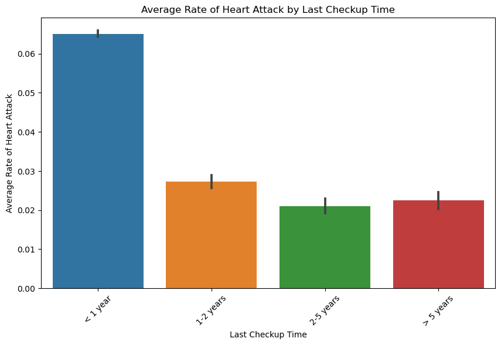

```python
sliced_dfC1 = sliced_df.copy()
sliced_dfC1['HadHeartAttackNumeric'] = sliced_dfC1['HadHeartAttack'].map({'Yes': 1, 'No': 0})

# calculating and sorting the rates of heart attacks across different checkup times
sort_order = [
    '< 1 year',
    '1-2 years',
    '2-5 years',
    '> 5 years'
]

sliced_dfC1['LastCheckupTime'] = pd.Categorical(sliced_dfC1['LastCheckupTime'], categories=sort_order, ordered=True)
sorted_data = sliced_dfC1.sort_values('LastCheckupTime')


# plotting the graph
plt.figure(figsize=(10, 6))
sns.barplot(x='LastCheckupTime', y='HadHeartAttackNumeric', data=sorted_data,)
plt.xlabel('Last Checkup Time')

plt.ylabel('Average Rate of Heart Attack')
plt.title('Average Rate of Heart Attack by Last Checkup Time')
plt.xticks(rotation=45)

plt.show()
```

The code below includes the functions that were used to plot the checkups against race. There are three functions: one without separate those who had and hadn’t suffered a heart attack, one for those who had suffered a heart attack, and one for those who hadn’t suffered a heart attack. The code plots them as a stacked bar graph with percentages that represent how much each portion takes up of the bar labeled on it. The are ordered from most to least recent in terms of checkup time from bottom to top.

```python
# No heart attack
def plot_stacked_checkup_by_race_no(sliced_df):
    filtered_df = sliced_df[sliced_df['HadHeartAttack'] == 'No']

    grouped = filtered_df.groupby(['RaceEthnicityCategory', 'LastCheckupTime']).size().unstack(fill_value=0)

    percentages = grouped.div(grouped.sum(axis=1), axis=0) * 100

    checkup_order = ['< 1 year', '1-2 years', '2-5 years', '> 5 years']

    percentages = percentages[checkup_order]

    ax = percentages.plot(kind='bar', stacked=True, figsize=(10, 6))

    plt.xlabel('Race/Ethnicity')
    plt.ylabel('Percentage')
    plt.title('No Heart Attack: Last Checkup Times within each Race/Ethnicity')
    plt.legend(title='Last Checkup Time', loc='lower right')
    plt.xticks(rotation=45)

    for rect in ax.patches:
        width, height = rect.get_width(), rect.get_height()
        x, y = rect.get_x(), rect.get_y()
        if height > 1:
            label_text = f'{height:.1f}%'
            ax.text(x + width / 2, y + height / 2, label_text, ha='center', va='center')

    plt.show()

# Yes heart attack
def plot_stacked_checkup_by_race_yes(sliced_df):

    filtered_df = sliced_df[sliced_df['HadHeartAttack'] == 'Yes']

    grouped = filtered_df.groupby(['RaceEthnicityCategory', 'LastCheckupTime']).size().unstack(fill_value=0)

    percentages = grouped.div(grouped.sum(axis=1), axis=0) * 100

    checkup_order = ['< 1 year', '1-2 years', '2-5 years', '> 5 years']

    percentages = percentages[checkup_order]

    ax = percentages.plot(kind='bar', stacked=True, figsize=(10, 6))

    plt.xlabel('Race/Ethnicity')
    plt.ylabel('Percentage')
    plt.title('Yes Heart Attack: Last Checkup Times within each Race/Ethnicity')
    plt.legend(title='Last Checkup Time', loc='lower right')
    plt.xticks(rotation=45)

    for rect in ax.patches:
        width, height = rect.get_width(), rect.get_height()
        x, y = rect.get_x(), rect.get_y()
        if height > 1:
            label_text = f'{height:.1f}%'
            ax.text(x + width / 2, y + height / 2, label_text, ha='center', va='center')

    plt.show()

# Yes and no heart attack
def plot_stacked_checkup_by_race(sliced_df):

    grouped = sliced_df.groupby(['RaceEthnicityCategory', 'LastCheckupTime']).size().unstack(fill_value=0)

    percentages = grouped.div(grouped.sum(axis=1), axis=0) * 100

    checkup_order = ['< 1 year', '1-2 years', '2-5 years', '> 5 years']

    percentages = percentages[checkup_order]

    ax = percentages.plot(kind='bar', stacked=True, figsize=(10, 6))

    plt.xlabel('Race/Ethnicity')
    plt.ylabel('Percentage')
    plt.title('Last Checkup Times within each Race/Ethnicity')
    plt.legend(title='Last Checkup Time', loc='lower right')
    plt.xticks(rotation=45)

    # labeling
    for rect in ax.patches:
        width, height = rect.get_width(), rect.get_height()
        x, y = rect.get_x(), rect.get_y()
        if height > 1:
            label_text = f'{height:.1f}%'
            ax.text(x + width / 2, y + height / 2, label_text, ha='center', va='center')

    plt.show()
```

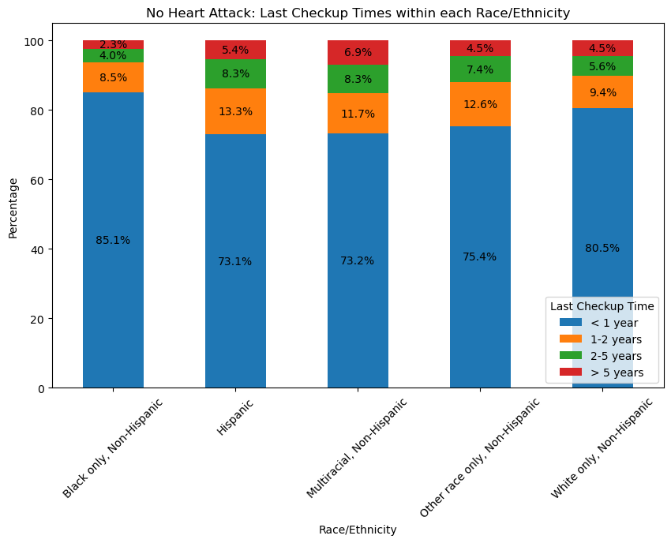

```python
plot_stacked_checkup_by_race_no(sliced_df)
```

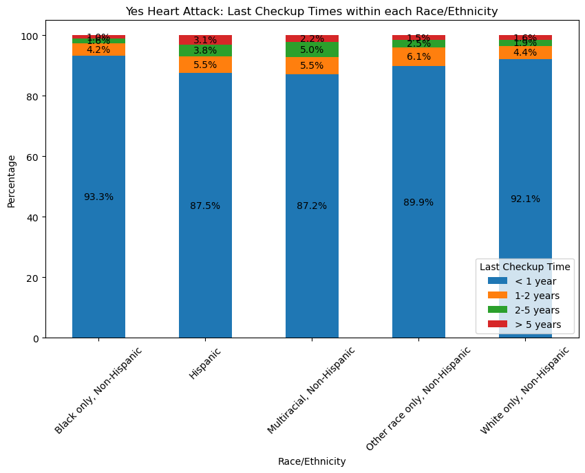

```python
plot_stacked_checkup_by_race_yes(sliced_df)
```

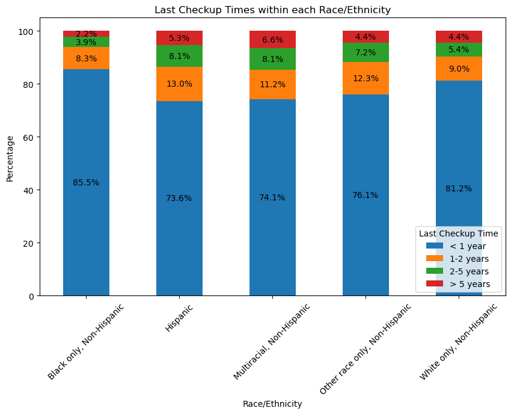

```python
plot_stacked_checkup_by_race(sliced_df)
```

### 2.3 Lifestyle Analysis

*By Ethan Sterling*

How do lifestyle choices, such as PhysicalActivities, SleepHours, SmokerStatus, ECigaretteUsage, AlcoholDrinkers, and other relevant variables, correlate with the occurrence of heart attacks among individuals in the dataset?

#### 2.3.1 Data cleaning and preparation

```python
lifestyle_choices = heart_data.loc[:,[
    'PhysicalActivities', 'SleepHours', 'SmokerStatus', 'ECigaretteUsage',
    'AlcoholDrinkers', 'HadHeartAttack', 'GeneralHealth']].copy()
```

```python
#data cleaning
missing_values = lifestyle_choices.isnull().sum()
print("Missing Values:\n", missing_values)

# Drop entries with missing values in the lifestyle_choices columns
lifestyle_choices_cleaned = lifestyle_choices.dropna()

# Verify that missing values have been dropped
missing_values_cleaned = lifestyle_choices_cleaned.isnull().sum()
print("\nMissing Values after cleaning:\n", missing_values_cleaned)
```

```
Missing Values:
 PhysicalActivities     1093
SleepHours             5453
SmokerStatus          35462
ECigaretteUsage       35660
AlcoholDrinkers       46574
HadHeartAttack         3065
GeneralHealth          1198
dtype: int64

Missing Values after cleaning:
 PhysicalActivities    0
SleepHours            0
SmokerStatus          0
ECigaretteUsage       0
AlcoholDrinkers       0
HadHeartAttack        0
GeneralHealth         0
dtype: int64
```

```python
#checking size of cleaned data set to ensure there is enough entries to do EDA
lifestyle_choices_cleaned.shape
```

```
(386782, 7)
```

#### 2.3.2 Sleep

*Let’s first look at the variable SleepHours as it is our only continuous variable in the lifestyle_choices_cleaned dataframe:*

```
Descriptive Statistics:
                    count      mean       std  min  25%  50%  75%   max
HadHeartAttack
No              365017.0  7.020588  1.445694  1.0  6.0  7.0  8.0  24.0
Yes              21765.0  7.050448  1.915061  1.0  6.0  7.0  8.0  24.0
T-statistic: 2.8992326523245633
P-value: 0.003740982399692232
Reject the null hypothesis: There is a significant difference in sleep hours between those who had a heart attack and those who did not.
```

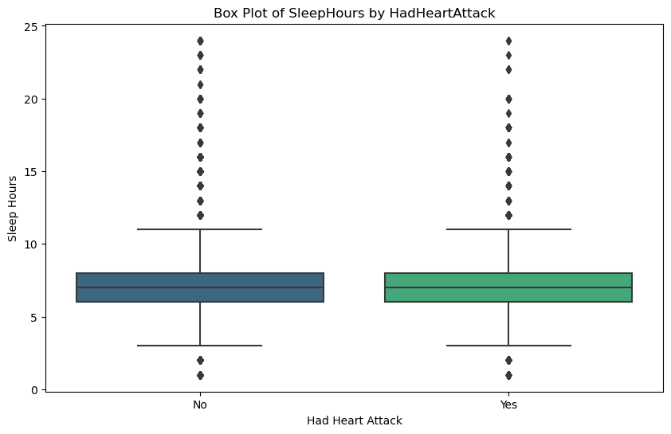

```python
# Select relevant columns
sleep_and_heart_attack_cleaned = lifestyle_choices_cleaned[['SleepHours', 'HadHeartAttack']]

# Descriptive Statistics
print("Descriptive Statistics:\n", sleep_and_heart_attack_cleaned.groupby('HadHeartAttack')['SleepHours'].describe())

# Visualization - Box Plot
plt.figure(figsize=(10, 6))
sns.boxplot(x='HadHeartAttack', y='SleepHours', data=sleep_and_heart_attack_cleaned, palette='viridis')
plt.title('Box Plot of SleepHours by HadHeartAttack')
plt.xlabel('Had Heart Attack')
plt.ylabel('Sleep Hours')
plt.show()

# Statistical Test - t-test
from scipy.stats import ttest_ind

had_heart_attack = sleep_and_heart_attack_cleaned[sleep_and_heart_attack_cleaned['HadHeartAttack'] == 'Yes']['SleepHours']
no_heart_attack = sleep_and_heart_attack_cleaned[sleep_and_heart_attack_cleaned['HadHeartAttack'] == 'No']['SleepHours']

t_stat, p_value = ttest_ind(had_heart_attack, no_heart_attack)

print(f"T-statistic: {t_stat}")
print(f"P-value: {p_value}")

# Interpretation of the t-test
alpha = 0.05
if p_value < alpha:
    print("Reject the null hypothesis: There is a significant difference in sleep hours between those who had a heart attack and those who did not.")
else:
    print("Fail to reject the null hypothesis: There is no significant difference in sleep hours between those who had a heart attack and those who did not.")
```

**Result:**

- The t-test indicates a statistically significant difference in mean sleep hours between individuals who had a heart attack and those who did not.
- However, it’s important to note that while the difference is statistically significant, the practical significance may be limited given the small difference in means (0.03 hours) and the large sample size.
- This could be due to older people, who are more likely to have heart attacks, also sleeping more, confounding the SleepHours variable
- This could also be due to people who had heart attacks beginning to sleep more.

#### 2.3.3 Categorical Variables

*Now let’s look at the rest of our variables:*

```
Descriptive Statistics for PhysicalActivities:
 HadHeartAttack  PhysicalActivities
No              No                     82203
                Yes                   282814
Yes             No                      8383
                Yes                    13382
dtype: int64

Chi-Square Test for Independence between HadHeartAttack and PhysicalActivities:
Chi-Square Statistic: 2929.33518174273
P-value: 0.0
Reject the null hypothesis: There is a significant association between HadHeartAttack and PhysicalActivities.

==================================================

Descriptive Statistics for SmokerStatus:
 HadHeartAttack  SmokerStatus
No              Current smoker - now smokes every day     30273
                Current smoker - now smokes some days     11850
                Former smoker                             97780
                Never smoked                             225114
Yes             Current smoker - now smokes every day      2924
                Current smoker - now smokes some days       889
                Former smoker                              9163
                Never smoked                               8789
dtype: int64

Chi-Square Test for Independence between HadHeartAttack and SmokerStatus:
Chi-Square Statistic: 3957.64404555045
P-value: 0.0
Reject the null hypothesis: There is a significant association between HadHeartAttack and SmokerStatus.

==================================================

Descriptive Statistics for ECigaretteUsage:
 HadHeartAttack  ECigaretteUsage
No              Never used e-cigarettes in my entire life    278893
                Not at all (right now)                        66212
                Use them every day                             9412
                Use them some days                            10500
```

[output cut: 12 more lines]

```

Descriptive Statistics for AlcoholDrinkers:
 HadHeartAttack  AlcoholDrinkers
No              No                 166929
                Yes                198088
Yes             No                  13464
                Yes                  8301
dtype: int64

Chi-Square Test for Independence between HadHeartAttack and AlcoholDrinkers:
Chi-Square Statistic: 2146.4091208836617
P-value: 0.0
Reject the null hypothesis: There is a significant association between HadHeartAttack and AlcoholDrinkers.

==================================================
```

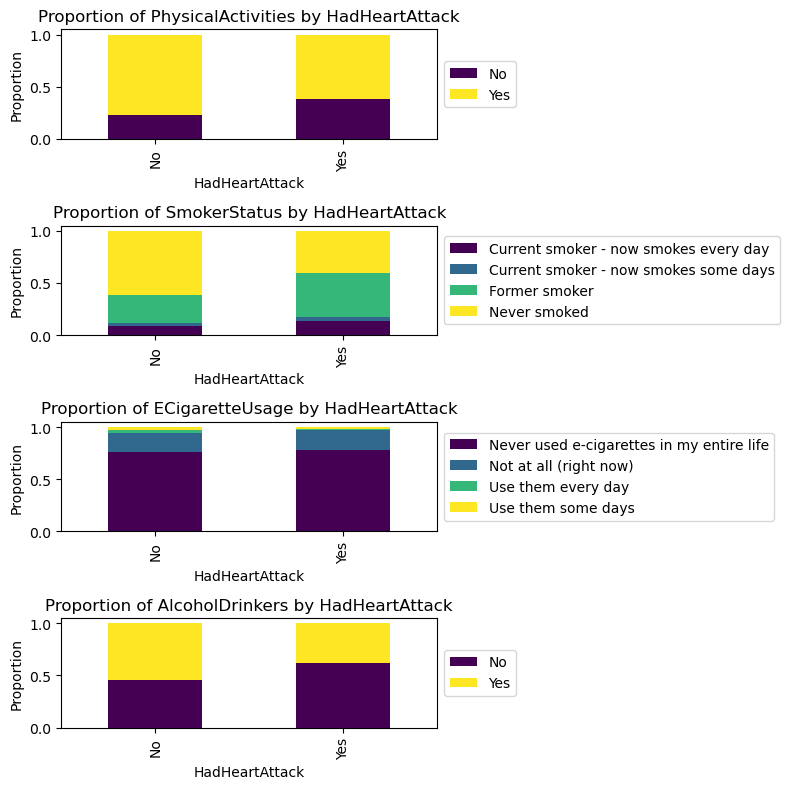

```python
# Select relevant categorical columns
categorical_variables = ['PhysicalActivities', 'SmokerStatus', 'ECigaretteUsage', 'AlcoholDrinkers']

# Create subplots
fig, axes = plt.subplots(nrows=len(categorical_variables), ncols=1, figsize=(8, 2 * len(categorical_variables)))

# Iterate through categorical variables
for i, variable in enumerate(categorical_variables):

    # Descriptive Statistics
    print(f"Descriptive Statistics for {variable}:\n", lifestyle_choices_cleaned.groupby(['HadHeartAttack', variable]).size())

    # Statistical Test - Chi-Square Test
    contingency_table = pd.crosstab(lifestyle_choices_cleaned['HadHeartAttack'], lifestyle_choices_cleaned[variable])
    chi2_stat, p_value, _, _ = chi2_contingency(contingency_table)

    print(f"\nChi-Square Test for Independence between HadHeartAttack and {variable}:")
    print(f"Chi-Square Statistic: {chi2_stat}")
    print(f"P-value: {p_value}")

    if p_value < alpha:
        print(f"Reject the null hypothesis: There is a significant association between HadHeartAttack and {variable}.")
    else:
        print(f"Fail to reject the null hypothesis: There is no significant association between HadHeartAttack and {variable}.")

    print("\n" + "="*50 + "\n")  # Add a separator for better readability

    # Visualization - Proportion Plot
    proportions = contingency_table.div(contingency_table.sum(axis=1), axis=0)
    ax = proportions.plot(kind='bar', stacked=True, ax=axes[i], colormap='viridis')
    ax.legend(loc='center left', bbox_to_anchor=(1, 0.5))  # Move the legend to the right side
    axes[i].set_title(f'Proportion of {variable} by HadHeartAttack')
    axes[i].set_xlabel('HadHeartAttack')
    axes[i].set_ylabel('Proportion')

# Adjust layout
plt.tight_layout()
plt.show()
```

**Physical Activities:**

- Descriptive Statistics: Individuals who had a heart attack are less likely to engage in physical activities.
- Chi-Square Test: A significant association exists between having a heart attack and the level of physical activities.

**Smoker Status:**

- Descriptive Statistics: Current smokers, both daily and occasional, show a higher prevalence of heart attacks.
- Chi-Square Test: A significant association is observed between smoker status and the likelihood of having a heart attack.

**E-Cigarette Usage:**

- Descriptive Statistics: Individuals who had a heart attack are less likely to use e-cigarettes.
- Chi-Square Test: A significant association exists between e-cigarette usage and the likelihood of having a heart attack.

**Alcohol Drinkers:**

- Descriptive Statistics: Non-alcohol drinkers show a higher prevalence of heart attacks.
- Chi-Square Test: A significant association is observed between alcohol drinking habits and the likelihood of having a heart attack.

**Interpretation:**

- These results suggest that lifestyle choices such as physical activities, smoking habits (both traditional and e-cigarettes), and alcohol consumption are associated with the likelihood of having a heart attack.
- The significance of these associations emphasizes the importance of lifestyle modifications in heart disease prevention.
- These findings could inform public health initiatives and personalized interventions to reduce the risk of heart attacks, especially targeting individuals with certain lifestyle behaviors.

**Caution:**

- While statistically significant, the observed associations do not imply causation.
- The results are based on observational data, and other confounding factors may contribute to the associations.

#### 2.3.4 Correlations

*Let’s see which of our lifestyle decisions are the most correlated with reducing heart attacks:*

```python
#Bin SleepHours

lifestyle_choices_cleaned_subset = lifestyle_choices_cleaned[['SleepHours', 'HadHeartAttack']].copy()

# Define bin edges based on quartiles
bin_edges = [0, 6, 7, 8, 24]

# Define bin labels
bin_labels = ['Very Low', 'Low', 'Moderate', 'High']

# Bin SleepHours
lifestyle_choices_cleaned['SleepHoursBin'] = pd.cut(lifestyle_choices_cleaned_subset['SleepHours'], bins=bin_edges, labels=bin_labels)

# Display the resulting DataFrame
lifestyle_choices_cleaned[['SleepHours', 'SleepHoursBin', 'HadHeartAttack']].head()
```

|  | SleepHours | SleepHoursBin | HadHeartAttack |
| --- | --- | --- | --- |
| 0 | 8.0 | Moderate | No |
| 1 | 6.0 | Very Low | No |
| 2 | 5.0 | Very Low | No |
| 3 | 7.0 | Low | No |
| 4 | 9.0 | High | No |

```python
categorical_variables = ['PhysicalActivities', 'SmokerStatus', 'ECigaretteUsage', 'AlcoholDrinkers', 'SleepHoursBin']

# Function to calculate Cramér's V
def cramers_v(confusion_matrix):
    chi2 = chi2_contingency(confusion_matrix)[0]
    n = confusion_matrix.sum().sum()
    phi2 = chi2 / n
    r, k = confusion_matrix.shape
    phi2corr = max(0, phi2 - ((k - 1) * (r - 1)) / (n - 1))
    rcorr = r - ((r - 1) ** 2) / (n - 1)
    kcorr = k - ((k - 1) ** 2) / (n - 1)
    return np.sqrt(phi2corr / min((kcorr - 1), (rcorr - 1)))

# Calculate Cramér's V for each variable
for variable in categorical_variables:
    contingency_table = pd.crosstab(lifestyle_choices_cleaned['HadHeartAttack'], lifestyle_choices_cleaned[variable])
    cramers_value = cramers_v(contingency_table)

    print(f"Cramér's V for {variable}: {cramers_value}")
```

```
Cramér's V for PhysicalActivities: 0.08701173459376996
Cramér's V for SmokerStatus: 0.1011162914857799
Cramér's V for ECigaretteUsage: 0.022647862318860828
Cramér's V for AlcoholDrinkers: 0.07447705496961607
Cramér's V for SleepHoursBin: 0.061105593132255616
```

```python
lifestyle_choices_cleaned = lifestyle_choices_cleaned.dropna()
lifestyle_dummy = pd.get_dummies(lifestyle_choices_cleaned)
lifestyle_dummy.corr().loc['HadHeartAttack_Yes']
```

```
SleepHours                                                   0.004662
PhysicalActivities_No                                        0.087040
PhysicalActivities_Yes                                      -0.087040
SmokerStatus_Current smoker - now smokes every day           0.042293
SmokerStatus_Current smoker - now smokes some days           0.010822
SmokerStatus_Former smoker                                   0.078892
SmokerStatus_Never smoked                                   -0.100355
ECigaretteUsage_Never used e-cigarettes in my entire life    0.010324
ECigaretteUsage_Not at all (right now)                       0.001702
ECigaretteUsage_Use them every day                          -0.018294
ECigaretteUsage_Use them some days                          -0.013109
AlcoholDrinkers_No                                           0.074506
AlcoholDrinkers_Yes                                         -0.074506
HadHeartAttack_No                                           -1.000000
HadHeartAttack_Yes                                           1.000000
GeneralHealth_Excellent                                     -0.078504
GeneralHealth_Fair                                           0.112428
GeneralHealth_Good                                           0.006651
GeneralHealth_Poor                                           0.144430
GeneralHealth_Very good                                     -0.087686
SleepHoursBin_Very Low                                       0.022564
SleepHoursBin_Low                                           -0.048587
SleepHoursBin_Moderate                                      -0.000682
SleepHoursBin_High                                           0.043827
Name: HadHeartAttack_Yes, dtype: float64
```

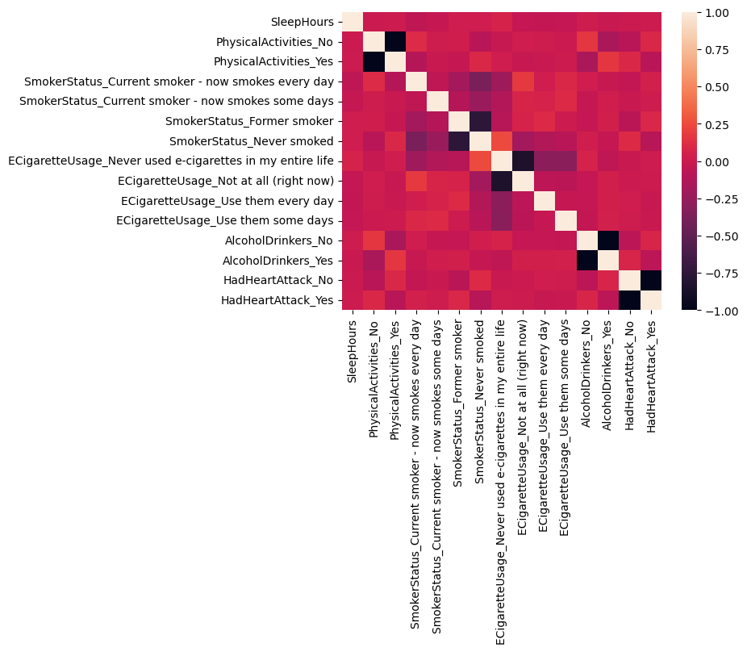

```python
sns.heatmap(lifestyle_dummy.drop(columns=['GeneralHealth_Excellent', 'GeneralHealth_Fair',
                                          'GeneralHealth_Good', 'GeneralHealth_Poor',
                                          'GeneralHealth_Very good', 'SleepHoursBin_Very Low',
                                          'SleepHoursBin_Low', 'SleepHoursBin_Moderate',
                                          'SleepHoursBin_High']).corr())
```

**Some things I found interesting so far:**

- More sleep is correlated with heart attacks. I believe this is due to confounding variables such as sleep being correlated with age and age being correlated with heart attacks. I will control for age below.
- Drinking alcohol is correlated with not having heart attacks. I will check what drinking alcohol is correlated with to see if there are any confounding variables.

#### 2.3.5 Controlling for age when looking at sleep’s correlation with heart attacks

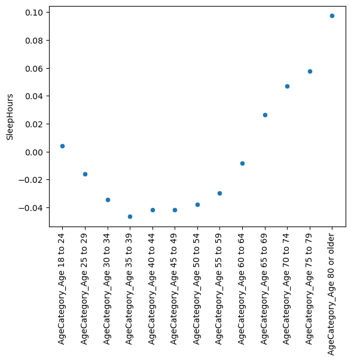

```python
# Checking correlation between sleep and age
corr_sleep_age = pd.get_dummies(heart_data[['AgeCategory','SleepHours']]).corr().iloc[1:,0]
sns.scatterplot(corr_sleep_age)
plt.xticks(rotation=90)
plt.show()
```

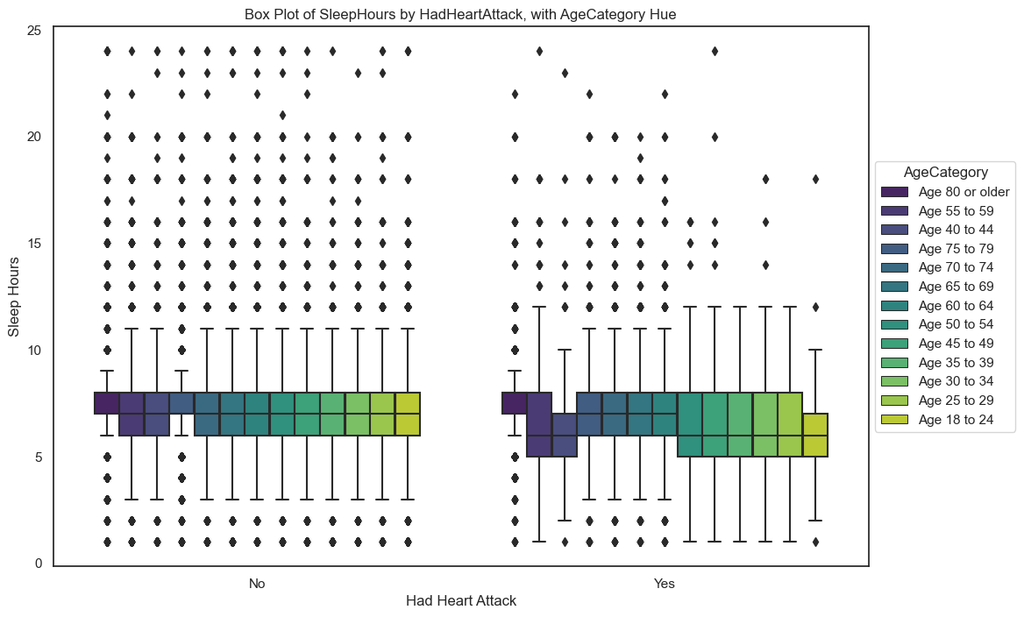

```python
# Merge based on 'AgeCategory'
merged_data = pd.concat([lifestyle_choices_cleaned, heart_data[['AgeCategory']]], axis=1)

# Drop missing values
merged_data= merged_data.dropna()

# Select relevant columns
merged_data_subset = merged_data[['SleepHours', 'HadHeartAttack', 'AgeCategory']].copy()

# Set the style for the plot
sns.set(style="white")

# Plot the boxplot
plt.figure(figsize=(12, 8))
sns.boxplot(x='HadHeartAttack', y='SleepHours', hue='AgeCategory', data=merged_data_subset, palette='viridis')
plt.title('Box Plot of SleepHours by HadHeartAttack, with AgeCategory Hue')
plt.xlabel('Had Heart Attack')
plt.ylabel('Sleep Hours')
plt.legend(title='AgeCategory', title_fontsize='12', loc='center left', bbox_to_anchor=(1, 0.5))
plt.show()
```

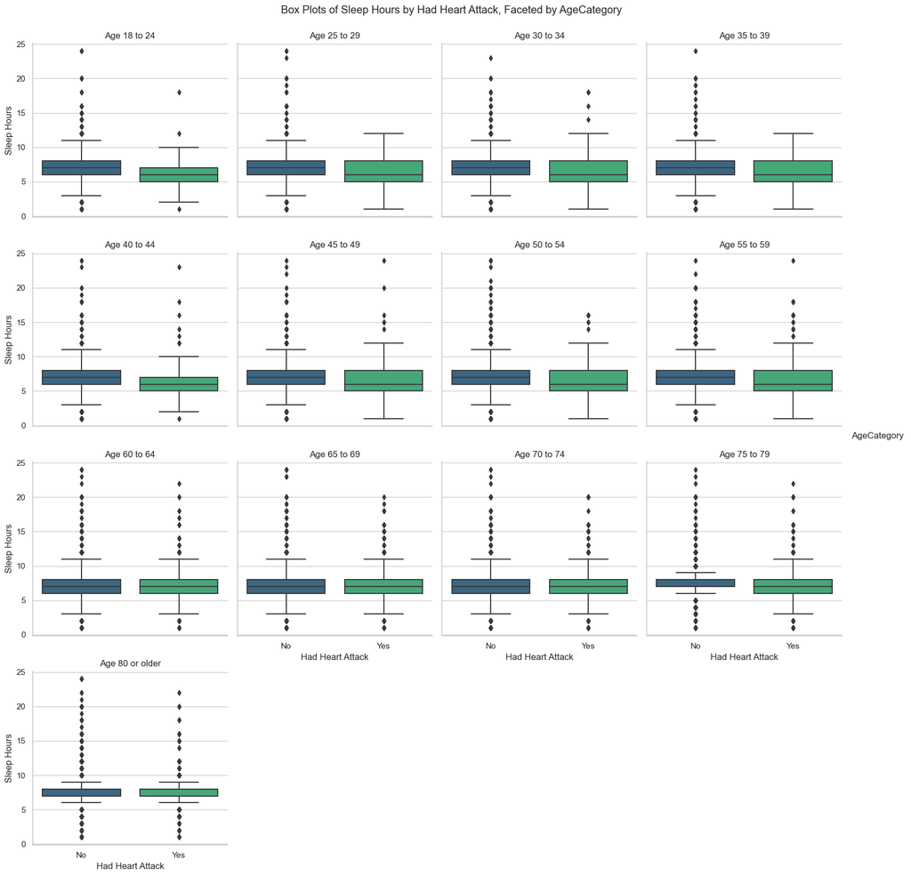

```python
# Define the order of AgeCategory in increasing order
age_category_order = ['Age 18 to 24', 'Age 25 to 29', 'Age 30 to 34', 'Age 35 to 39',
                       'Age 40 to 44', 'Age 45 to 49', 'Age 50 to 54', 'Age 55 to 59',
                       'Age 60 to 64', 'Age 65 to 69', 'Age 70 to 74', 'Age 75 to 79', 'Age 80 or older']

# Define the order of HadHeartAttack
had_heart_attack_order = ['No', 'Yes']

# Set the style for the plot
sns.set(style="whitegrid")

# Create a FacetGrid with boxplots
g = sns.FacetGrid(merged_data_subset, col='AgeCategory', col_wrap=4, height=4, palette='viridis', col_order=age_category_order)
g.map(sns.boxplot, 'HadHeartAttack', 'SleepHours', palette='viridis', order=had_heart_attack_order)
g.set_axis_labels('Had Heart Attack', 'Sleep Hours')
g.set_titles(col_template="{col_name}")
g.add_legend(title='AgeCategory', title_fontsize='12')
plt.suptitle('Box Plots of Sleep Hours by Had Heart Attack, Faceted by AgeCategory', y=1.02)
plt.show()
```

```python
# Set the significance level
alpha = 0.05

# Perform t-test for each age category
for age_category in age_category_order:
    # Select data for the current age category
    current_age_category_data = merged_data_subset[merged_data_subset['AgeCategory'] == age_category]

    # Extract SleepHours for 'Yes' and 'No' HadHeartAttack
    had_heart_attack = current_age_category_data[current_age_category_data['HadHeartAttack'] == 'Yes']['SleepHours']
    no_heart_attack = current_age_category_data[current_age_category_data['HadHeartAttack'] == 'No']['SleepHours']

    # Perform t-test
    t_stat, p_value = ttest_ind(had_heart_attack, no_heart_attack)

    # Calculate the mean difference
    mean_difference = had_heart_attack.mean() - no_heart_attack.mean()

    # Print results
    print(f"\nAge Category: {age_category}")
    print(f"T-statistic: {t_stat}")
    print(f"P-value: {p_value}")
    print(f"Mean Difference: {mean_difference}")

    # Interpretation of the t-test
    if p_value < alpha:
        print("Reject the null hypothesis: There is a significant difference in sleep hours between those who had a heart attack and those who did not.")
    else:
        print("Fail to reject the null hypothesis: There is no significant difference in sleep hours between those who had a heart attack and those who did not.")
```

```
Age Category: Age 18 to 24
T-statistic: -5.1902447218468675
P-value: 2.117512926810855e-07
Mean Difference: -0.7689049354565878
Reject the null hypothesis: There is a significant difference in sleep hours between those who had a heart attack and those who did not.

Age Category: Age 25 to 29
T-statistic: -3.9722989033901825
P-value: 7.14395862633239e-05
Mean Difference: -0.5770811807336624
Reject the null hypothesis: There is a significant difference in sleep hours between those who had a heart attack and those who did not.

Age Category: Age 30 to 34
T-statistic: -4.147749865520774
P-value: 3.36997428747115e-05
Mean Difference: -0.45899608425600924
Reject the null hypothesis: There is a significant difference in sleep hours between those who had a heart attack and those who did not.

Age Category: Age 35 to 39
T-statistic: -7.029125969664643
P-value: 2.132006988258105e-12
Mean Difference: -0.5790961601041325
Reject the null hypothesis: There is a significant difference in sleep hours between those who had a heart attack and those who did not.

Age Category: Age 40 to 44
T-statistic: -7.2884912735571845
P-value: 3.2237958705515823e-13
Mean Difference: -0.5236186400577783
Reject the null hypothesis: There is a significant difference in sleep hours between those who had a heart attack and those who did not.

Age Category: Age 45 to 49
T-statistic: -8.662824552238959
P-value: 4.878590501969374e-18
Mean Difference: -0.49593562088469945
Reject the null hypothesis: There is a significant difference in sleep hours between those who had a heart attack and those who did not.

Age Category: Age 50 to 54
T-statistic: -8.16079911744948
P-value: 3.460211349418336e-16
Mean Difference: -0.36647094012687287
```

[output cut: 22 more lines]

```
P-value: 0.02037590359187661
Mean Difference: -0.058805571367741116
Reject the null hypothesis: There is a significant difference in sleep hours between those who had a heart attack and those who did not.

Age Category: Age 75 to 79
T-statistic: -0.4566026682556771
P-value: 0.6479601369065546
Mean Difference: -0.012517186333018238
Fail to reject the null hypothesis: There is no significant difference in sleep hours between those who had a heart attack and those who did not.

Age Category: Age 80 or older
T-statistic: -0.08210530877824912
P-value: 0.9345635069160441
Mean Difference: -0.0021318537289340966
Fail to reject the null hypothesis: There is no significant difference in sleep hours between those who had a heart attack and those who did not.
```

**Age Categories without Significant Differences:**

- For ‘Age 75 to 79’ and ‘Age 80 or older’, the p-values are greater than the significance level (0.05). Therefore, we fail to reject the null hypothesis in these age categories, indicating no significant difference in sleep hours between individuals who had a heart attack and those who did not.

```python
mean_differences = [-0.7689049354565878, -0.5770811807336624, -0.45899608425600924,
                    -0.5790961601041325, -0.5236186400577783, -0.49593562088469945,
                    -0.36647094012687287, -0.25943166655729843, -0.2505429168762898,
                    -0.12058938127005359, -0.058805571367741116]

# Calculate the overall mean difference
overall_mean_difference = sum(mean_differences) / len(mean_differences)

# Print the overall mean difference
print(f"Overall Mean Difference for Significant Age Categories: {overall_mean_difference}")
```

```
Overall Mean Difference for Significant Age Categories: -0.40540664524464776
```

```python
# Convert 'Yes' and 'No' to 1 and 0 in 'HadHeartAttack'
merged_data_subset['HadHeartAttack'] = merged_data_subset['HadHeartAttack'].map({'Yes': 1, 'No': 0})

# Group by 'AgeCategory' and calculate the correlation
correlation_by_age_category = merged_data_subset.groupby('AgeCategory')[['SleepHours', 'HadHeartAttack']].corr().iloc[0::2, -1]
print(correlation_by_age_category)
```

```
AgeCategory
Age 18 to 24     SleepHours   -0.033717
Age 25 to 29     SleepHours   -0.028519
Age 30 to 34     SleepHours   -0.027718
Age 35 to 39     SleepHours   -0.044542
Age 40 to 44     SleepHours   -0.045152
Age 45 to 49     SleepHours   -0.055007
Age 50 to 54     SleepHours   -0.047620
Age 55 to 59     SleepHours   -0.039069
Age 60 to 64     SleepHours   -0.041075
Age 65 to 69     SleepHours   -0.021926
Age 70 to 74     SleepHours   -0.011816
Age 75 to 79     SleepHours   -0.002703
Age 80 or older  SleepHours   -0.000469
Name: HadHeartAttack, dtype: float64
```

#### 2.3.6 Finding confounding variables for alcohol consumption

*Wow that was cool! Lets take a look at drinking:*

|  | AlcoholDrinkers_Yes |
| --- | --- |
| SleepHours | -0.008549 |
| PhysicalActivities_No | -0.160179 |
| PhysicalActivities_Yes | 0.160179 |
| SmokerStatus_Current smoker - now smokes every day | -0.017819 |
| SmokerStatus_Current smoker - now smokes some days | 0.024143 |
| SmokerStatus_Former smoker | 0.033807 |
| SmokerStatus_Never smoked | -0.029532 |
| ECigaretteUsage_Never used e-cigarettes in my entire life | -0.060333 |
| ECigaretteUsage_Not at all (right now) | 0.033385 |
| ECigaretteUsage_Use them every day | 0.031960 |
| ECigaretteUsage_Use them some days | 0.046540 |
| AlcoholDrinkers_No | -1.000000 |
| AlcoholDrinkers_Yes | 1.000000 |
| HadHeartAttack_No | 0.074506 |
| HadHeartAttack_Yes | -0.074506 |

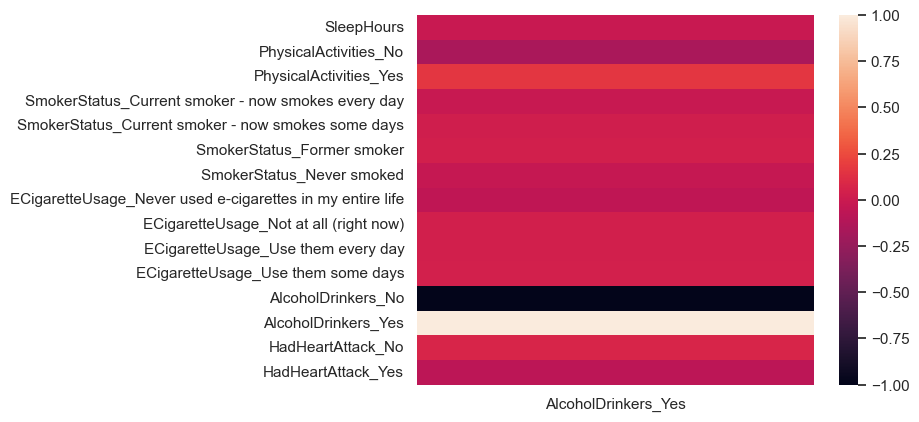

```python
sns.heatmap(lifestyle_dummy.drop(columns=['GeneralHealth_Excellent', 'GeneralHealth_Fair',
                                          'GeneralHealth_Good', 'GeneralHealth_Poor',
                                          'GeneralHealth_Very good', 'SleepHoursBin_Very Low',
                                          'SleepHoursBin_Low', 'SleepHoursBin_Moderate',
                                          'SleepHoursBin_High']).corr()[['AlcoholDrinkers_Yes']])

lifestyle_dummy.drop(columns=['GeneralHealth_Excellent', 'GeneralHealth_Fair',
                              'GeneralHealth_Good', 'GeneralHealth_Poor',
                              'GeneralHealth_Very good', 'SleepHoursBin_Very Low',
                              'SleepHoursBin_Low', 'SleepHoursBin_Moderate',
                              'SleepHoursBin_High']).corr()[['AlcoholDrinkers_Yes']]
```

Lets look at physical activity, smoking, and ECigarette usage:

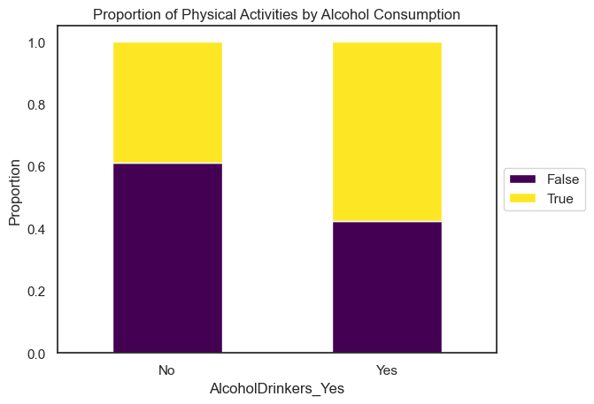

```python
# Create a DataFrame for Physical Activities
physical_activities_df = lifestyle_dummy[['PhysicalActivities_No', 'PhysicalActivities_Yes', 'AlcoholDrinkers_Yes']]

# Proportion Barplot for Physical Activities
contingency_table_physical_activities = pd.crosstab(physical_activities_df['PhysicalActivities_Yes'], physical_activities_df['AlcoholDrinkers_Yes'])
proportions_physical_activities = contingency_table_physical_activities.div(contingency_table_physical_activities.sum(axis=1), axis=0)
proportions_physical_activities.index = proportions_physical_activities.index.map({0: 'No', 1: 'Yes'})

sns.set_style("white")
ax_physical_activities = proportions_physical_activities.plot(kind='bar', stacked=True, colormap='viridis')
ax_physical_activities.legend(['False', 'True'], loc='center left', bbox_to_anchor=(1, 0.5))
ax_physical_activities.set_title('Proportion of Physical Activities by Alcohol Consumption')
ax_physical_activities.set_xlabel('AlcoholDrinkers_Yes')
ax_physical_activities.set_ylabel('Proportion')
ax_physical_activities.set_xticklabels(ax_physical_activities.get_xticklabels(), rotation=0)
plt.show()
```

```python
# Function to create barplots for each category
def create_barplots(category_df, title_prefix):
    fig, axes = plt.subplots(nrows=2, ncols=2, figsize=(12, 10))

    for i, category in enumerate(category_df.iloc[:, :4].columns):
        contingency_table = pd.crosstab(category_df[category], category_df['AlcoholDrinkers_Yes'])
        proportions = contingency_table.div(contingency_table.sum(axis=1), axis=0)
        proportions.index = proportions.index.map({0: 'No', 1: 'Yes'})  # Replace 0 and 1 labels
        ax = proportions.plot(kind='bar', stacked=True, colormap='viridis', ax=axes[i // 2, i % 2])
        ax.legend(['False', 'True'], loc='center left', bbox_to_anchor=(1, 0.5))
        ax.set_title(f'{title_prefix} {category} by Alcohol Consumption')
        ax.set_xlabel('Alcohol Drinkers')
        ax.set_xticklabels(ax.get_xticklabels(), rotation=0)
        ax.set_ylabel('Proportion')

    plt.tight_layout()
    plt.show()
```

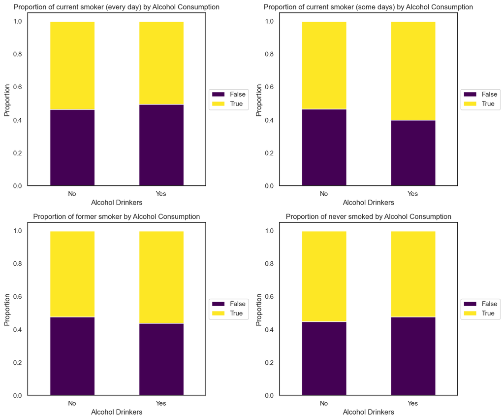

```python
# Create a DataFrame for Smoker Status
smoker_status_df = lifestyle_dummy[['SmokerStatus_Current smoker - now smokes every day',
                                    'SmokerStatus_Current smoker - now smokes some days',
                                    'SmokerStatus_Former smoker',
                                    'SmokerStatus_Never smoked',
                                    'AlcoholDrinkers_Yes']].copy()

smoker_status_df.rename(columns={'SmokerStatus_Current smoker - now smokes every day': 'current smoker (every day)',
                                 'SmokerStatus_Current smoker - now smokes some days': 'current smoker (some days)',
                                 'SmokerStatus_Former smoker' : 'former smoker',
                                 'SmokerStatus_Never smoked' : 'never smoked'}, inplace=True)

# Create barplots for Smoker Status
create_barplots(smoker_status_df, 'Proportion of')
```

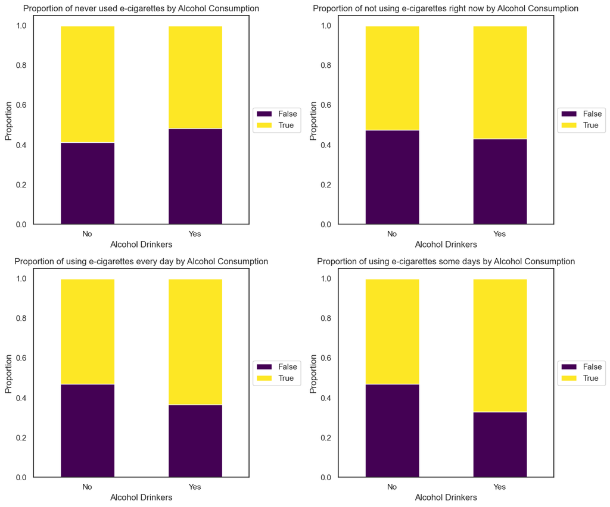

```python
# Create a DataFrame for E-Cigarette Usage
ecigarette_usage_df = lifestyle_dummy[['ECigaretteUsage_Never used e-cigarettes in my entire life',
                                       'ECigaretteUsage_Not at all (right now)',
                                       'ECigaretteUsage_Use them every day',
                                       'ECigaretteUsage_Use them some days',
                                       'AlcoholDrinkers_Yes']].copy()

ecigarette_usage_df.rename(columns={'ECigaretteUsage_Never used e-cigarettes in my entire life': 'never used e-cigarettes',
                                    'ECigaretteUsage_Not at all (right now)': 'not using e-cigarettes right now',
                                    'ECigaretteUsage_Use them every day' : 'using e-cigarettes every day',
                                    'ECigaretteUsage_Use them some days' : 'using e-cigarettes some days'}, inplace=True)

# Create barplots for E-Cigarette Usage
create_barplots(ecigarette_usage_df, 'Proportion of')
```

**Interpretation:**

- Based on these visualizations, the only significant difference in proportion between those who drink alcohol and those who don’t is the participation in physical activity. Approximately 20% more people engage in a physical activity among those who drink alcohol compared to those who don’t. This could be due to the social aspect of physical activity. Engaging in physical activities, especially recreational sports or fitness classes, often involves social interaction. People may participate in these activities as part of a group or with friends, and social gatherings may include alcohol consumption. Physical activity is one of the most correlated lifestyle decision with preventing heart attacks, as seen in the previous correlations. This could explain why drinking alcohol correlates with fewer heart attacks.

```python
# Create a contingency table
contingency_table = pd.crosstab(lifestyle_choices_cleaned['HadHeartAttack'],
                                [lifestyle_choices_cleaned['PhysicalActivities'],
                                 lifestyle_choices_cleaned['AlcoholDrinkers']])

# Calculate proportions
proportions_no = contingency_table['No'].div(contingency_table['No'].sum(axis=1), axis=0)
proportions_yes = contingency_table['Yes'].div(contingency_table['Yes'].sum(axis=1), axis=0)
```

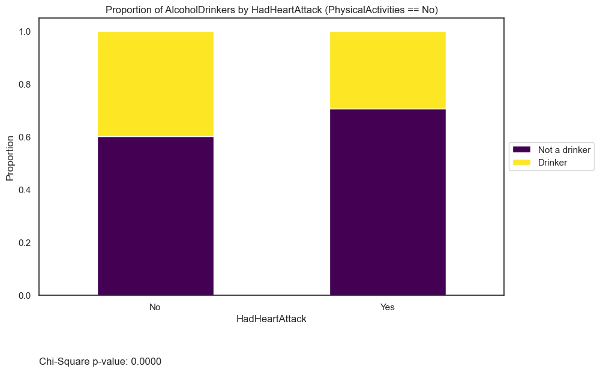

```python
# Plot the proportional bar plot for no PhysicalActivities
ax = proportions_no.plot(kind='bar', stacked=True, colormap='viridis', figsize=(10, 6))
ax.legend(['Not a drinker', 'Drinker'], loc='center left', bbox_to_anchor=(1, 0.5))
ax.set_title('Proportion of AlcoholDrinkers by HadHeartAttack (PhysicalActivities == No)')
ax.set_xlabel('HadHeartAttack')
ax.set_xticklabels(ax.get_xticklabels(), rotation=0)
ax.set_ylabel('Proportion')

# Perform chi-squared test for no PhysicalActivities
chi2_stat_no, p_value_no, _, _ = chi2_contingency(contingency_table['No'])
ax.text(0, -0.25, f'Chi-Square p-value: {p_value_no:.4f}', transform=ax.transAxes)

# Show the plot
plt.show()
```

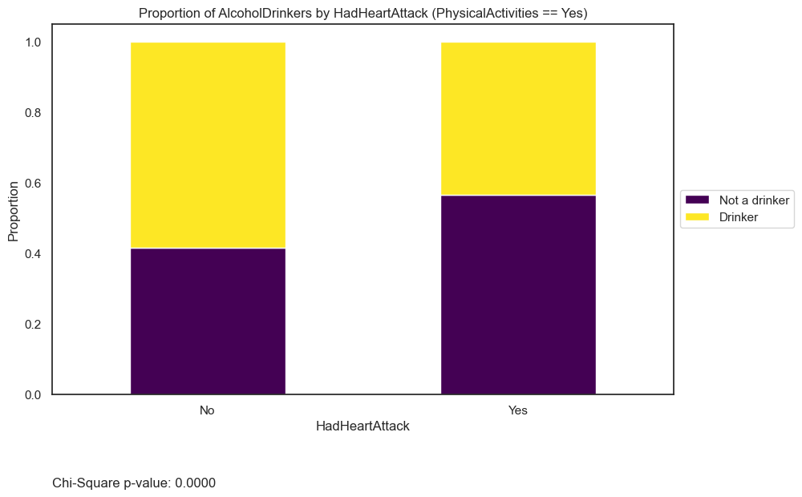

```python
# Plot the proportional bar plot for yes PhysicalActivities
ax = proportions_yes.plot(kind='bar', stacked=True, colormap='viridis', figsize=(10, 6))
ax.legend(['Not a drinker', 'Drinker'], loc='center left', bbox_to_anchor=(1, 0.5))
ax.set_title('Proportion of AlcoholDrinkers by HadHeartAttack (PhysicalActivities == Yes)')
ax.set_xlabel('HadHeartAttack')
ax.set_xticklabels(ax.get_xticklabels(), rotation=0)
ax.set_ylabel('Proportion')

# Perform chi-squared test for yes PhysicalActivities
chi2_stat_yes, p_value_yes, _, _ = chi2_contingency(contingency_table['Yes'])
ax.text(0, -0.25, f'Chi-Square p-value: {p_value_yes:.4f}', transform=ax.transAxes)

# Show the plot
plt.show()
```

**Result:**

- The p-values are less than 0.05 for both (PhysicalActivities == Yes) and (PhysicalActivities == No), meaning that drinking alcohol still has a positive correlation with not having a heart attack.

### 2.4 Underlying Conditions Analysis

*By Fauzan Aryaputra*

How do underlying health issues and vaccination statuses impact the risk of heart attacks and heart disease?

#### 2.4.1 Data cleaning and preparation

```python
#Creating a copy of the dataset so as to not mess up my teammates' datasets
f_heart_data = heart_data.copy()
```

```python
f_heart_data['HadHeartAttack'].isnull().sum()
```

```
3065
```

```python
#The nature of the dataset is that we can treat each variable and HadHeartAttack as its own dataset, so to clean NA values
#we only have to remove the ones of the variable in question. Create function that does that automatically.

def drop_null_values(col):
    return f_heart_data[f_heart_data[col].notna()]
```

```python
# Creating a dictionary for states so I can map it to the dataframe in a way that allows for it to be used by plotly
states = {'AK': 'Alaska','AL': 'Alabama','AR': 'Arkansas','AS': 'American Samoa','AZ': 'Arizona','CA': 'California', 'CO': 'Colorado','CT': 'Connecticut','DC': 'District of Columbia','DE': 'Delaware','FL': 'Florida','GA': 'Georgia','HI': 'Hawaii','ID': 'Idaho','IA': 'Iowa', 'IL': 'Illinois','IN': 'Indiana','KS': 'Kansas','KY': 'Kentucky','LA': 'Louisiana','ME': 'Maine','MD': 'Maryland','MA': 'Massachusetts','MI': 'Michigan','MN': 'Minnesota','MS': 'Mississippi','MO': 'Missouri','MT': 'Montana','NE': 'Nebraska','NV': 'Nevada','NH': 'New Hampshire','NJ': 'New Jersey','NM': 'New Mexico','NY': 'New York','NC': 'North Carolina','ND': 'North Dakota','OH': 'Ohio','OK': 'Oklahoma','OR': 'Oregon','PA': 'Pennsylvania','RI': 'Rhode Island','SC': 'South Carolina','SD': 'South Dakota','TN': 'Tennessee','TX': 'Texas','UT': 'Utah','VT': 'Vermont','VA': 'Virginia','WA': 'Washington','WV': 'West Virginia','WI': 'Wisconsin','WY': 'Wyoming'}
inv_states = {v: k for k, v in states.items()}
mainland_states = ['AL','AK','AZ','AR','CA','CO','CT','DE', 'DC', 'FL','GA','HI','ID','IL','IN','IA','KS','KY','LA','ME', 'MD','MA','MI','MN','MS','MO','MT','NE','NV','NH','NJ','NM','NY','NC','ND','OH','OK','OR','PA','RI','SC','SD','TN','TX','UT','VT','VA','WA','WV','WI','WY']
f_heart_data["State"] = f_heart_data['State'].replace(inv_states)
```

```python
#Getting dummy data to change yes-no to boolean value
heart_attack_dummies = pd.get_dummies(f_heart_data['HadHeartAttack'])
f_heart_data["HadHeartAttack"] = heart_attack_dummies.loc[:, "Yes"]
```

#### 2.4.2 BMI and heart attacks

The intention with this section is to see the correlation between BMI and heart attacks, if any.

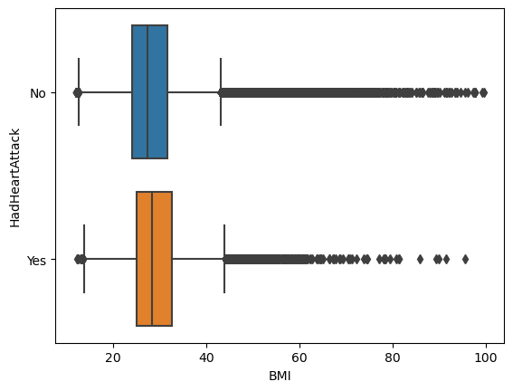

```python
#Roughly explore relationship by comparing barplots.
sns.boxplot(data = heart_data,x = 'BMI', y = "HadHeartAttack")
plt.show()
```

```python
heart_attack_yes = f_heart_data[f_heart_data["HadHeartAttack"] == True]
heart_attack_no = f_heart_data[f_heart_data["HadHeartAttack"] == False]
```

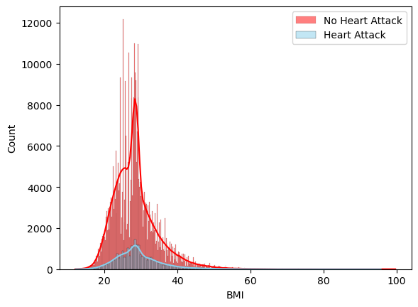

```python
sns.histplot(data=heart_attack_no, x="BMI", color="red", label="No Heart Attack", kde=True)
sns.histplot(data=heart_attack_yes, x="BMI", color="skyblue", label="Heart Attack", kde=True)
plt.legend()
plt.xlabel('BMI')
plt.show()
```

```python
#Run hypothesis test of difference of means
stat, pval = scipy.stats.ttest_ind(heart_attack_yes["BMI"], heart_attack_no["BMI"], nan_policy='omit')
mean_diff = heart_attack_yes["BMI"].mean() - heart_attack_no["BMI"].mean()

print("The p-value is " + ("%.3g" % pval))
print("The difference in BMI means is",  mean_diff)
```

```
The p-value is 1.69e-79
The difference in BMI means is 0.8399708138100266
```

Important to note with a dataset this large, any hypothesis test we run will have a very low p-value. Still, this indicates that there is a correlation between individuals with higher BMIs with an increased likelihood of heart attacks.

```python
#Getting heart attack proportion by state
data_to_map = f_heart_data[f_heart_data["State"].isin(mainland_states)]
heart_attack_prop_map_values = data_to_map.groupby("State")["HadHeartAttack"].sum()/data_to_map.groupby("State")["HadHeartAttack"].count()
```

```python
#Getting BMI by state
bmi_map_values = data_to_map.groupby("State")["BMI"].mean()
```

```python
def create_map(map_data, color, legend_title, title_text):
    fig = go.Figure(data=go.Choropleth(
        locations= mainland_states, # Spatial coordinates
        z = map_data, # Data to be color-coded
        locationmode = 'USA-states', # set of locations match entries in `locations`
        colorscale = color,
        colorbar_title = legend_title
    ))

    fig.update_layout(
        title_text = title_text,
        geo_scope='usa', # limite map scope to USA
    )

    fig.show()
```

```python
#Heart attack proportion map
create_map(heart_attack_prop_map_values, "reds", "Heart attack proportion", "Heart attack proportion by state")
```

[interactive chart not shown]

```python
#Average BMI map
create_map(bmi_map_values, "blues", "Average BMI", "Average BMI by state")
```

[interactive chart not shown]

```python
#Get non NA values to prep for ANOVA test
f_heart_data = f_heart_data[f_heart_data["BMI"].notna()]
```

```python
#Looks correlated. Let's double check whether they are correlated with ANOVA analysis. Use significance level p = 0.05.
scipy.stats.f_oneway(f_heart_data[f_heart_data["State"] == 'AL']["BMI"],
                             f_heart_data[f_heart_data["State"] == 'AK']["BMI"],
                             f_heart_data[f_heart_data["State"] == 'AZ']["BMI"],
                             f_heart_data[f_heart_data["State"] == 'AR']["BMI"],
                             f_heart_data[f_heart_data["State"] == 'CA']["BMI"],
                             f_heart_data[f_heart_data["State"] == 'CO']["BMI"],
                             f_heart_data[f_heart_data["State"] == 'CT']["BMI"],
                             f_heart_data[f_heart_data["State"] == 'DE']["BMI"],
                             f_heart_data[f_heart_data["State"] == 'DC']["BMI"],
                             f_heart_data[f_heart_data["State"] == 'FL']["BMI"],
                             f_heart_data[f_heart_data["State"] == 'GA']["BMI"],
                             f_heart_data[f_heart_data["State"] == 'HI']["BMI"],
                             f_heart_data[f_heart_data["State"] == 'ID']["BMI"],
                             f_heart_data[f_heart_data["State"] == 'IL']["BMI"],
                             f_heart_data[f_heart_data["State"] == 'IN']["BMI"],
                             f_heart_data[f_heart_data["State"] == 'IA']["BMI"],
                             f_heart_data[f_heart_data["State"] == 'KS']["BMI"],
                             f_heart_data[f_heart_data["State"] == 'KY']["BMI"],
                             f_heart_data[f_heart_data["State"] == 'LA']["BMI"],
                             f_heart_data[f_heart_data["State"] == 'ME']["BMI"],
                             f_heart_data[f_heart_data["State"] == 'MD']["BMI"],
                             f_heart_data[f_heart_data["State"] == 'MA']["BMI"],
                             f_heart_data[f_heart_data["State"] == 'MI']["BMI"],
                             f_heart_data[f_heart_data["State"] == 'MN']["BMI"],
                             f_heart_data[f_heart_data["State"] == 'MS']["BMI"],
                             f_heart_data[f_heart_data["State"] == 'MO']["BMI"],
                             f_heart_data[f_heart_data["State"] == 'MT']["BMI"],
                             f_heart_data[f_heart_data["State"] == 'NE']["BMI"],
                             f_heart_data[f_heart_data["State"] == 'NV']["BMI"],
                             f_heart_data[f_heart_data["State"] == 'NH']["BMI"],
                             f_heart_data[f_heart_data["State"] == 'NJ']["BMI"],
                             f_heart_data[f_heart_data["State"] == 'NM']["BMI"],
                             f_heart_data[f_heart_data["State"] == 'NY']["BMI"],
                             f_heart_data[f_heart_data["State"] == 'NC']["BMI"],
                             f_heart_data[f_heart_data["State"] == 'ND']["BMI"],
                             f_heart_data[f_heart_data["State"] == 'OH']["BMI"],
                             f_heart_data[f_heart_data["State"] == 'OK']["BMI"],
                             f_heart_data[f_heart_data["State"] == 'OR']["BMI"],
                             f_heart_data[f_heart_data["State"] == 'PA']["BMI"],
                             f_heart_data[f_heart_data["State"] == 'RI']["BMI"],
                             f_heart_data[f_heart_data["State"] == 'SC']["BMI"],
                             f_heart_data[f_heart_data["State"] == 'SD']["BMI"],
                             f_heart_data[f_heart_data["State"] == 'TN']["BMI"],
                             f_heart_data[f_heart_data["State"] == 'TX']["BMI"],
                             f_heart_data[f_heart_data["State"] == 'UT']["BMI"],
                             f_heart_data[f_heart_data["State"] == 'VT']["BMI"],
                             f_heart_data[f_heart_data["State"] == 'VA']["BMI"],
                             f_heart_data[f_heart_data["State"] == 'WA']["BMI"],
                             f_heart_data[f_heart_data["State"] == 'WV']["BMI"],
                             f_heart_data[f_heart_data["State"] == 'WI']["BMI"],
                             f_heart_data[f_heart_data["State"] == 'WY']["BMI"])
```

```
F_onewayResult(statistic=73.60617044156776, pvalue=0.0)
```

High F statistic and low p-value (so low such that scipy outputs 0) means that there is certainly a correlation between states and BMI. Will impute BMI by average of state.

```python
#Reinclude all the null values
f_heart_data = heart_data.copy()
f_heart_data["State"] = f_heart_data['State'].replace(inv_states)
f_heart_data = f_heart_data[f_heart_data["State"].isin(mainland_states)]
```

```python
state_means = f_heart_data["BMI"].groupby(f_heart_data["State"]).mean()
f_heart_null = f_heart_data[f_heart_data["BMI"].isna()].copy()
```

```python
def impute_bmi(row):
    state = row['State']
    return state_means[state]
```

```python
f_heart_null.head()
```

|  | State | Sex | GeneralHealth | PhysicalHealthDays | MentalHealthDays | LastCheckupTime | PhysicalActivities | SleepHours | RemovedTeeth | HadHeartAttack | ... | HeightInMeters | WeightInKilograms | BMI | AlcoholDrinkers | HIVTesting | FluVaxLast12 | PneumoVaxEver | TetanusLast10Tdap | HighRiskLastYear | CovidPos |
| --- | --- | --- | --- | --- | --- | --- | --- | --- | --- | --- | --- | --- | --- | --- | --- | --- | --- | --- | --- | --- | --- |
| 0 | AL | Female | Very good | 0.0 | 0.0 | Within past year (anytime less than 12 months ... | No | 8.0 | NaN | No | ... | NaN | NaN | NaN | No | No | Yes | No | Yes, received tetanus shot but not sure what type | No | No |
| 8 | AL | Female | Good | 0.0 | 0.0 | Within past year (anytime less than 12 months ... | Yes | 6.0 | NaN | No | ... | 1.7 | NaN | NaN | No | Yes | No | No | Yes, received tetanus shot but not sure what type | No | No |
| 22 | AL | Female | Fair | 30.0 | 0.0 | Within past year (anytime less than 12 months ... | Yes | 7.0 | NaN | No | ... | NaN | 47.63 | NaN | NaN | NaN | NaN | NaN | NaN | NaN | NaN |
| 38 | AL | Male | Very good | 8.0 | 0.0 | Within past year (anytime less than 12 months ... | Yes | 6.0 | NaN | Yes | ... | NaN | NaN | NaN | NaN | NaN | NaN | NaN | NaN | NaN | NaN |
| 60 | AL | Male | Poor | 30.0 | 15.0 | Within past year (anytime less than 12 months ... | Yes | 8.0 | NaN | No | ... | NaN | NaN | NaN | NaN | NaN | NaN | NaN | NaN | NaN | NaN |

5 rows × 40 columns

```python
f_heart_imputed = f_heart_null.copy()
f_heart_imputed['BMI'] = f_heart_null.apply(impute_bmi, axis=1)
```

```python
f_heart_imputed['BMI'].isna().sum()
#Perfect!
```

```
0
```

```python
f_heart_data = pd.concat([f_heart_data[f_heart_data["BMI"].notna()], f_heart_imputed])
f_heart_data['BMI'].isna().sum()
```

```
0
```

```python
heart_attack_dummies = pd.get_dummies(f_heart_data['HadHeartAttack'])
f_heart_data["HadHeartAttack"] = heart_attack_dummies.loc[:, "Yes"]
```

```python
#Successfully imputed!
#Redo difference in mean test to see if there are any differences:

f_heart_attack_yes = f_heart_data[f_heart_data["HadHeartAttack"] == True]
f_heart_attack_no = f_heart_data[f_heart_data["HadHeartAttack"] == False]

stat, pval = scipy.stats.ttest_ind(f_heart_attack_yes["BMI"], f_heart_attack_no["BMI"])
mean_diff = f_heart_attack_yes["BMI"].mean() - f_heart_attack_no["BMI"].mean()

print("The p-value is " + ("%.3g" % pval))
print("The difference in BMI means is",  mean_diff)
```

```
The p-value is 8.21e-84
The difference in BMI means is 0.7868642618899457
```

After re-running the difference in mean hypothesis test, the p-value is lower than before but so is the difference in BMI means. The difference in BMI means is quite small, less than one BMI unit, so maybe controlling for state would yield a greater difference in BMI? It was something I considered, but quickly realized made no intuitive sense. I then realized that another way to quantify BMI’s relationship with heart attacks would be analyzing it per state, and finding the correlation between average state BMI and proportion of population with heart attacks. This would give greater insight than just a difference in mean values by turning the categorical binary heart attack variable into a continuous one.

```python
state_bmi_comp = pd.concat([state_means, heart_attack_prop_map_values], axis=1).reset_index()
state_bmi_comp["Region"] = ""
```

```python
def get_region(x):
    west = ['WA', 'OR', 'CA', 'NV', 'ID', 'UT', 'MT', 'WY', 'CO', 'AK', 'HI']
    southwest = ['AZ', 'NM', 'TX', 'OK']
    midwest = ['ND', 'SD', 'NE', 'KS', 'MN', 'IA', 'MO', 'WI', 'IL', 'MI', 'IN', 'OH']
    southeast = ['AR', 'LA', 'MS', 'AL', 'TN', 'KY', 'WV', 'VA', 'NC', 'SC', 'GA', 'FL']
    northeast = ['ME', 'NH', 'VT', 'MA', 'RI', 'CT', 'NY', 'NJ', 'PA', 'DE', 'MD', 'DC']

    if x["State"] in west:
        return 'West'
    elif x["State"] in southwest:
        return 'Southwest'
    elif x["State"] in midwest:
        return 'Midwest'
    elif x["State"] in southeast:
        return 'Southeast'
    elif x["State"] in northeast:
        return 'Northeast'
```

```python
state_bmi_comp["Region"] = state_bmi_comp.apply(get_region, axis= 1)
```

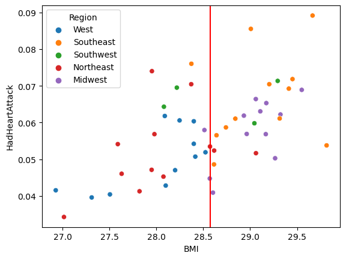

```python
sns.scatterplot(data = state_bmi_comp, x = "BMI", y = "HadHeartAttack", hue = "Region")
plt.axvline(state_bmi_comp["BMI"].median(), color='red')
plt.show()
```

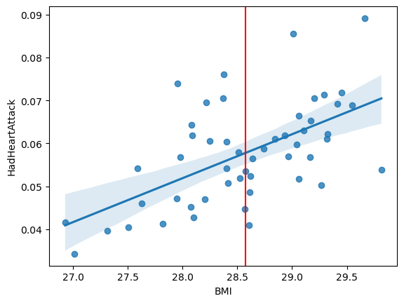

```python
sns.regplot(data = state_bmi_comp, x = "BMI", y = "HadHeartAttack")
plt.axvline(state_bmi_comp["BMI"].median(), color='red')
plt.show()
```

```python
state_bmi_comp.groupby("Region")[["BMI", "HadHeartAttack"]].agg("mean").sort_values(by = "BMI").corr()
```

|  | BMI | HadHeartAttack |
| --- | --- | --- |
| BMI | 1.000000 | 0.798384 |
| HadHeartAttack | 0.798384 | 1.000000 |

```python
#Quantify BMI effect
quantiles = f_heart_data["BMI"].quantile([0.25, 0.5, 0.75])
def get_BMI_quantile(x):
    if x["BMI"] <= quantiles[0.25]:
        return "1"
    elif x["BMI"] <= quantiles[0.5]:
        return "2"
    elif x["BMI"] <= quantiles[0.75]:
        return "3"
    else:
        return "4"
```

```python
f_heart_data["BMI Quantile"] = ""
```

```python
f_heart_data["BMI Quantile"] = f_heart_data.apply(get_BMI_quantile, axis = 1)
```

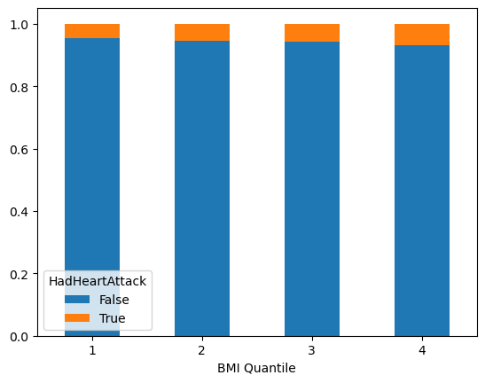

```python
bmi_table = pd.crosstab(f_heart_data['BMI Quantile'], f_heart_data["HadHeartAttack"], normalize = 'index')
ax = bmi_table.plot(kind='bar', stacked=True)
plt.xticks(rotation = 0)
plt.show()
```

```python
bmi_table
```

| HadHeartAttack BMI Quantile | False | True |
| --- | --- | --- |
| 1 | 0.953626 | 0.046374 |
| 2 | 0.945124 | 0.054876 |
| 3 | 0.943240 | 0.056760 |
| 4 | 0.931612 | 0.068388 |

```python
0.068388/0.046374
```

```
1.4747056540302756
```

Individuals in the top 25% of BMIs are 47% more likely to get a heart attack as compared to individuals in the bottom 25%.